# Raster and vector data cubes in R

May 22, 2019, Jena [edzer.github.io/jena/](https://edzer.github.io/jena) ([rmd](https://github.com/edzer/jena/blob/master/cubes.Rmd))

## What are data cubes?

- They are annotated **array data**.
- Arrays map from \(n\) dimensions to \(p\) attributes: \[(D_1,D_2,...,D_n)\rightarrow (A_1,A_2,...,A_p)\]
- array dimensions are enumerated sets, and may
  - represent a set of entities (cities, persons, species, spectral bands)
  - discretize a continuous variable, such as
    - spatial *dimension*,
    - time,
    - time-of-day,
    - frequency or wavelength,
    - duration (e.g., time-to-forecast)

## “Cube”:

We use the word *cube* short for

- “real” cube: three dimensions
- more than three dimensions: hypercube
- two dimensions: matrix, raster

a special case is:

- one dimensional cube: table with records (`data.frame`, `tibble`)

## “Spatial” data cube

Cube dimensions can refer to spatial dimensions in several ways:

- each continuous spatial dimension (x, y, z) maps to a **single** cube dimension (**raster** data cubes), e.g. regular grids
  - \(c(i) = o + (i-1) \times \delta, \ \ i = 1,2,...,n\)
  - index space is continuous: integer \(i\) implies \([i,i+1)\)
  - this means that every coordinate value maps to a unique index (unlike polygons)
- **all** spatial dimensions map to a single cube dimension (**vector** data cubes)
  - cube dimension is a set of points/lines/polygons
- combinations of these: e.g. origin-destination matrices

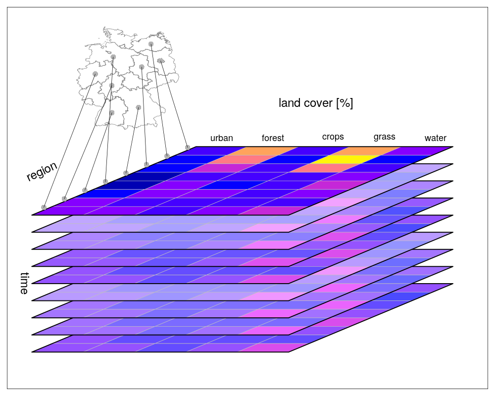

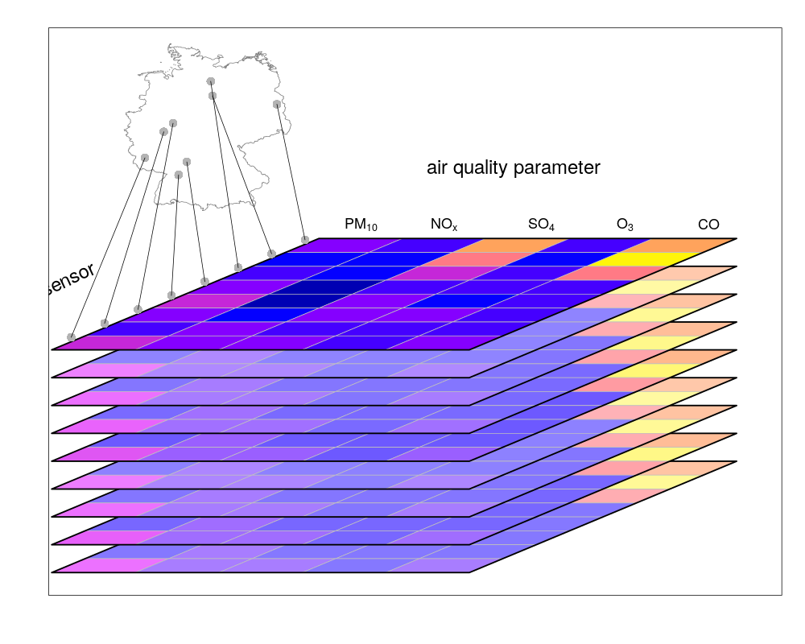

## Raster - vector conversion

From raster to vector:

- polygons or points are given:
  - sample (“extract”)
  - aggregate, e.g. mean or sum over polygon
- polygons or lines are the result:
  - polygonize
  - contour

From vector to raster:

- (points/polygons:) rasterize
- (point sample:) interpolate
- (point pattern:) density

## Raster types

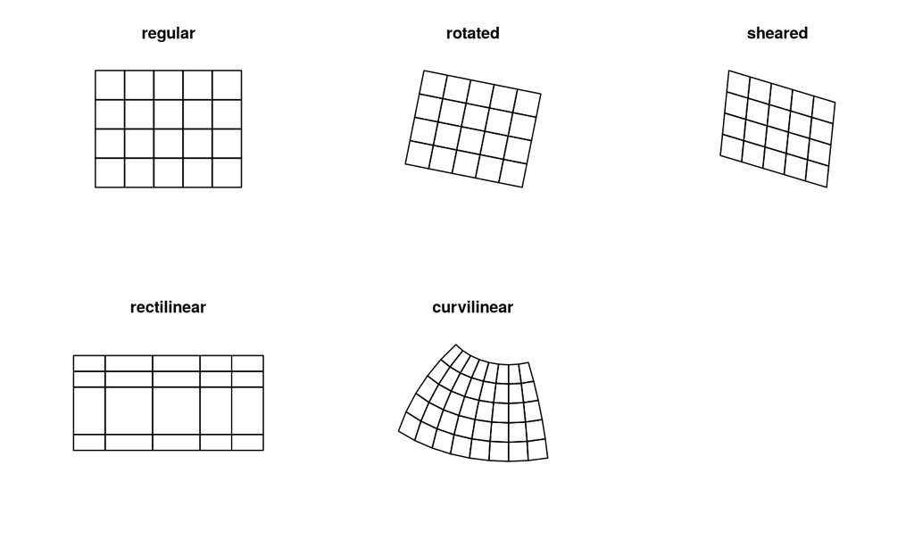

## R package `raster`

- is legacy, well understood, scales (automatically), powerful
- “limits” data size to data on (local) disk; will auto-chunk
- only implements *regular* raster, or a *stack* of these
- stack can be time-related
- pixels are scalar, real-valued (custom mimicing factors)
- Is anything is wrong with R’s native `array`? No!
- dimensions can be named, dimension values labeled:

```r
array(1:8/8, c(2,2,2), dimnames = list(dim_1=c("a","b"), dim_2=c("p", "q"),
     dim_3=c("x", "y")))
```

```
## , , dim_3 = x
##
##      dim_2
## dim_1     p     q
##     a 0.125 0.375
##     b 0.250 0.500
##
## , , dim_3 = y
##
##      dim_2
## dim_1     p     q
##     a 0.625 0.875
##     b 0.750 1.000
```

- but labels can only be `character`
- `dpyr::tbl_cube` improves on this, but still only accepts vectors, not handling regular, rectilinear boundaries, CRS, units, sheared/rotated, curvilinear, …
- arrays can only (sensibly) be atomic: no records with mixed fields
- arrays are in-memory (which **may** at some point change, e.g.~using `ALTREP`)

## R package `stars`

- a `stars` object is a *set* (`list`) of arrays with possibly varying type (numeric, integer, `factor`, `logical`, `character`, `list`)
- uses R’s native arrays for that: all `array` Ops work (pixel math)
- supports arrays with measurement units and time stamps (throug GDAL, libnetcdf)
- has a `dimensions` attribute “table”
- does everything in memory, unless you use `stars_proxy`, which does nothing in memory
- lets you define arbitrary number of dimensions
- slice & dice with `[`, or `filter`
- map/reduce with `st_apply`: apply a function to a (set of) dimension(s)
- `aggregate` for spatial / temporal aggregations
- supports rectilinear (all dims), rotated, sheared, and curvilinear grids (raster), and simple features (vector)

## R package `stars` (2)

- implements raster (GDAL, netcdf) and vector (`sfc`) data cubes
- full support for PROJ coordinate reference systems
- time support: `POSIXct`, `Date`, as well as `PCICt` (360, 365, noleap)
- integration with some tidyverse verbs (`filter`, `select`, `mutate`, `geom_stars`)
- integrates with `gstat` (spatial, spatiotemporal geostatistics)

```r
library(stars)
tif = system.file("tif/L7_ETMs.tif", package = "stars")
(x = read_stars(tif))
```

```
## stars object with 3 dimensions and 1 attribute
## attribute(s):
##   L7_ETMs.tif
##  Min.   :  1.00
##  1st Qu.: 54.00
##  Median : 69.00
##  Mean   : 68.91
##  3rd Qu.: 86.00
##  Max.   :255.00
## dimension(s):
##      from  to  offset delta                       refsys point values
## x       1 349  288776  28.5 +proj=utm +zone=25 +south... FALSE   NULL [x]
## y       1 352 9120761 -28.5 +proj=utm +zone=25 +south... FALSE   NULL [y]
## band    1   6      NA    NA                           NA    NA   NULL
```

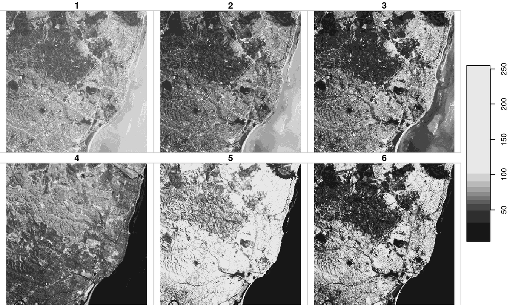

```r
plot(x)
```

## `stars_proxy` objects

- contain pointers to the data (file, URL), which by no means uniquely defines an array
- use a strategy to go through them (chunking: currently only spatial)
- are lazy: only compute when data is requested
- can read downsampled arrays (e.g. to `plot`): optimises execution order of call stack
- can time-compose e.g. a time stack of NetCDF files, with a time slice in each file

```r
granule = system.file("sentinel/S2A_MSIL1C_20180220T105051_N0206_R051_T32ULE_20180221T134037.zip", package = "starsdata")
base_name = strsplit(basename(granule), ".zip")[[1]]
s2 = paste0("SENTINEL2_L1C:/vsizip/", granule, "/", base_name, ".SAFE/MTD_MSIL1C.xml:10m:EPSG_32632")
(p = read_stars(s2, proxy = TRUE))
```

```
## stars_proxy object with 1 attribute in file:
## $`MTD_MSIL1C.xml:10m:EPSG_32632`
## [1] "SENTINEL2_L1C:/vsizip//home/edzer/R/x86_64-pc-linux-gnu-library/3.6/starsdata/sentinel/S2A_MSIL1C_20180220T105051_N0206_R051_T32ULE_20180221T134037.zip/S2A_MSIL1C_20180220T105051_N0206_R051_T32ULE_20180221T134037.SAFE/MTD_MSIL1C.xml:10m:EPSG_32632"
##
## dimension(s):
##      from    to offset delta                       refsys point values
## x       1 10980  3e+05    10 +proj=utm +zone=32 +datum...    NA   NULL [x]
## y       1 10980  6e+06   -10 +proj=utm +zone=32 +datum...    NA   NULL [y]
## band    1     4     NA    NA                           NA    NA   NULL
```

```r
object.size(p)
```

```
## 7336 bytes
```

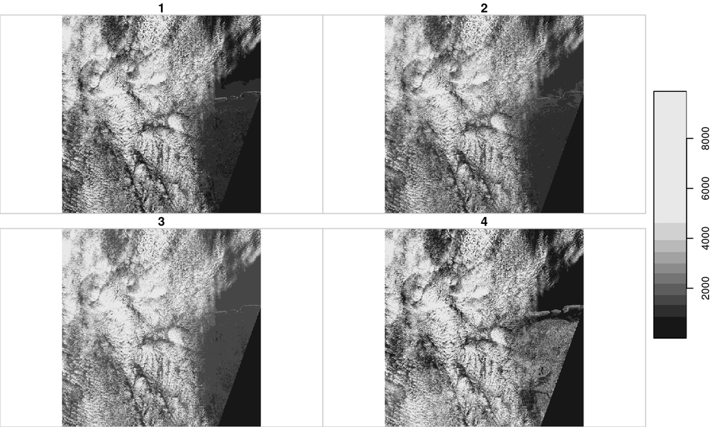

```
##    user  system elapsed
##   0.766   0.196   0.470
```

```r
system.time(plot(p))
```

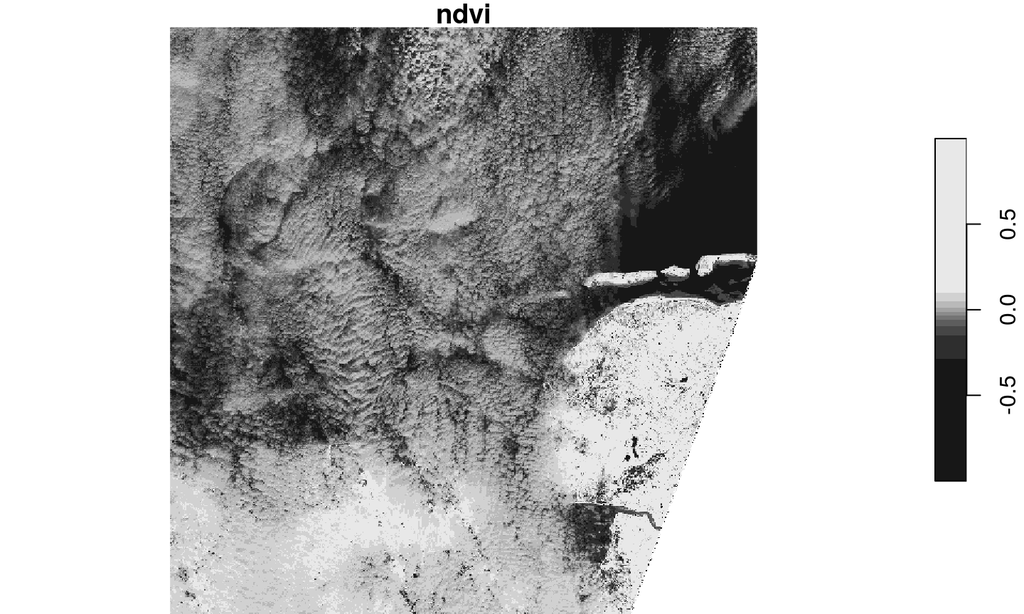

```
##    user  system elapsed
##   1.077   0.185   0.772
```

```r
ndvi = function(x) (x[4]-x[3])/(x[4]+x[3])
system.time(plot(st_apply(p, c("x", "y"), ndvi)))
```

## What if data are not nicely aligned in a cube?

- subsequent images have different, consecutive time stamps
- space is not rasterized (e.g., tiles in UTM zones)

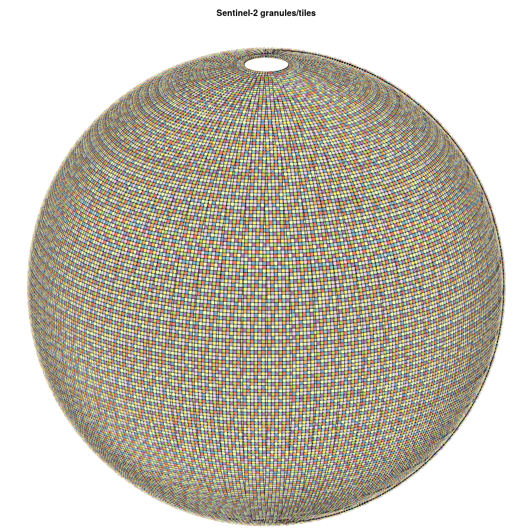

## `gdalcubes`:

- create and process Earth observation data cubes from GDAL image collections
- written by Marius Appel: [C++](https://github.com/appelmar/gdalcubes), [R interface](https://github.com/appelmar/gdalcubes_R)
- indexes a set of GDAL-readable files
- “reads” them, by resampling, to a user-defined data cube
- resampling options can be controlled (e.g. nearest, linear, bilinear) in both space and time
- can process this cube, in parallel (e.g., reduce, aggregate)
- writes the resulting data cube to a NetCDF file

[figure not shown]

## openEO : an API for cube processing

- is an H2020 project that develops a modern, open API to connect R, python, javascript and other clients to big Earth observation cloud back-ends in a simple and unified way.
- has (scalar-valued) raster and vector data cubes as its data primitive
- allows map/reduce, aggregation, resampling, user-defined data cubes, all math ops, ..
- allows for UDFs (user-defined functions, e.g. written in Python or R)
- anticipates a federated, heterogeneous cloud big EO data computing landscape (EOSC, DIAS, TEPs/MEPs…)

`stars` is somewhat of a blueprint, and useful client-side, or for server-side UDFs

## Wrapping up:

Get involved: try out stuff

- if you do, don’t hesitate to give feedback on r-sig-geo, github issues, or twitter

Further reading:

- the [CRAN landing page](https://cran.r-project.org/package=stars) for `stars` has five vignettes
- Spatial Data Science (with applications in R): r-spatial.org/book/
- my rstudio::conf 2019 talk: [spatial data science in the tidyverse](https://resources.rstudio.com/rstudio-conf-2019/spatial-data-science-in-the-tidyverse)

Finally:

- To make this fly, we only need a video.